# FinalExam-Nev-Simmons.R

# Part 2

```r
models.summary <- resamples(list(Logistic= diabetes.log,
                         SingleTree = diabetes.tree,
                         RandomForest= diabetes.rf))   #Find Accuracy Scores
summary(models.summary)
```

```
##
## Call:
## summary.resamples(object = models.summary)
##
## Models: Logistic, SingleTree, RandomForest
## Number of resamples: 50
##
## Accuracy
##                   Min.   1st Qu.    Median      Mean   3rd Qu.      Max. NA's
## Logistic     0.8301887 0.8633540 0.8750000 0.8764976 0.8873231 0.9250000    0
## SingleTree   0.8125000 0.8681309 0.8781398 0.8779032 0.8935829 0.9245283    0
## RandomForest 0.8509317 0.8867925 0.8944099 0.8976277 0.9105248 0.9437500    0
##
## Kappa
##                   Min.   1st Qu.    Median      Mean   3rd Qu.      Max. NA's
## Logistic     0.6441184 0.7138719 0.7372913 0.7404999 0.7620948 0.8420273    0
## SingleTree   0.5772799 0.7228064 0.7490741 0.7479793 0.7784509 0.8413965    0
## RandomForest 0.6802912 0.7563553 0.7802616 0.7827128 0.8088955 0.8805178    0
```

```r
diabetes_test %>%
  mutate(LogPred = predict(diabetes.log, newdata=diabetes_test),
         TreePred = predict(diabetes.tree, newdata=diabetes_test),
         RanForPred = predict(diabetes.rf, newdata=diabetes_test)) %>%
  summarize(LogAccuracy = mean(LogPred == diabetes),
            TreeAccuracy = mean(TreePred == diabetes),
            RanAccuracy = mean(RanForPred == diabetes))   #Test on Test Set
```

```
## # A tibble: 1 × 3
##   LogAccuracy TreeAccuracy RanAccuracy
##         <dbl>        <dbl>       <dbl>
## 1        0.89        0.895       0.875
```

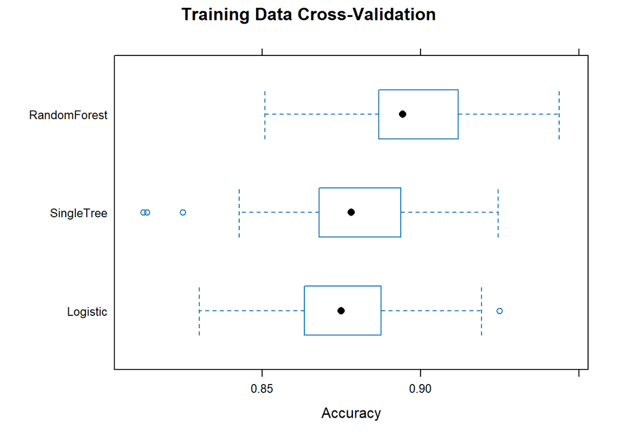

```r
BoxWhiskerPlot <- bwplot(models.summary, metric="Accuracy",
                         main = "Training Data Cross-Validation")
BoxWhiskerPlot
```

Since Diabetes was changed to a factored variable, we are no longer treating it with a continuous response variable. Now this variable is a factored variable that denotes either 1 or 0 and nothing in between. Based on our Accuracy values which shows the amount of agreement with the models predictions, we can find that in the training set the random forest tree although overlapping, seems to be the best at predicting the diabetes response variable based on using all of the predictors available. However, using the test set, the accuracy variable shows that the random forest was the worst performing method compared to the other two, and the regression tree was the best at prediction. This is most likely due to the overfitting that occurs when using every single predictor rather than using just four in the regression tree. The problem with this comparison is that one of the models “tree”, is using less predictors and this shows to be just slightly better at prediction rather than the simple logistic regression model, most likely due to the less amount of predictors and the more concise predictors chosen. There is also a lot of error when considering these models, with the over-lappage of these plots it may be hard to completely trust these results. A precision test could be useful here as it would tell us how many false positives are predicted by the results. Based on the value, we could determine if the true prediction test is worth using to predict Diabetes, as false positives are a big no-no in the medical field.

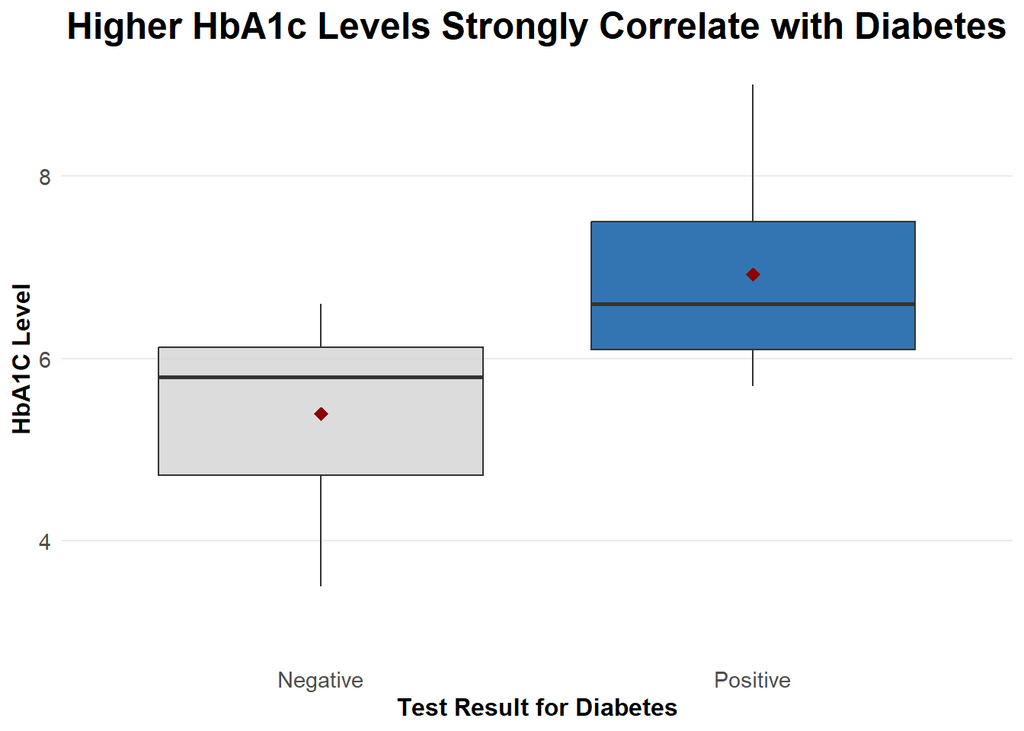

```r
HBA1cBoxPlot <- ggplot(diabetesdata) +
  geom_boxplot(aes(x = diabetes, y = HbA1c_level, fill = diabetes),
               alpha = 0.8, show.legend = FALSE) +
  stat_summary(aes(x = diabetes, y = HbA1c_level),
               fun = mean, geom = "point", shape = 18, size = 3, color = "darkred") +
  scale_y_continuous(limits = c(3, 9)) +
  scale_fill_manual(values = c("Negative" = "#d3d3d3", "Positive" = "#00539F")) +
  labs(title = "Higher HbA1c Levels Strongly Correlate with Diabetes",
       y = "HbA1C Level",
       x = "Test Result for Diabetes") +
  theme_minimal() +
  theme(plot.title = element_text(hjust = 0.5, size = 18, face = "bold"),
        axis.title = element_text(size = 12, face = "bold"),
        axis.text = element_text(size = 11),
        panel.grid.major.x = element_blank(),
        panel.grid.minor = element_blank())

HBA1cBoxPlot
```

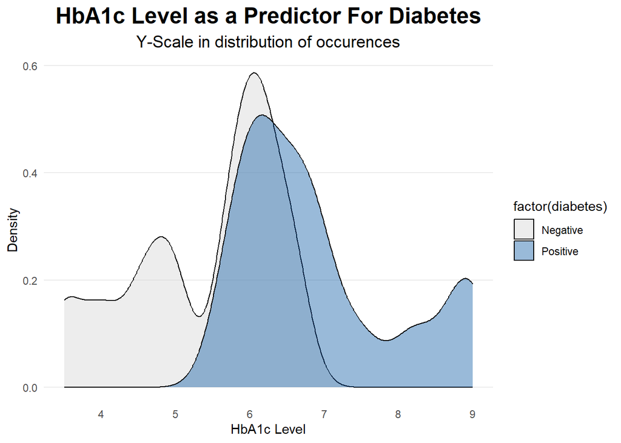

```r
HBA1cDensityPlot <- ggplot(diabetesdata, aes(x = HbA1c_level, fill = factor(diabetes))) +
  geom_density(alpha = 0.4) +
  scale_fill_manual(values = c("Negative" = "#d3d3d3", "Positive" = "#00539F")) +
  labs(title = "HbA1c Level as a Predictor For Diabetes",
       subtitle = "Y-Scale in distribution of occurences",
       y = "Density",
       x = "HbA1c Level") +
  theme_minimal() +
  theme(plot.title = element_text(hjust = 0.5, size = 18, face = "bold"),
        plot.subtitle = element_text(hjust = 0.5, size = 13.5),
        axis.title = element_text(size = 11),
        panel.grid.major.x = element_blank(),   #Get rid of horizontal lines
        panel.grid.minor = element_blank())
HBA1cDensityPlot
```

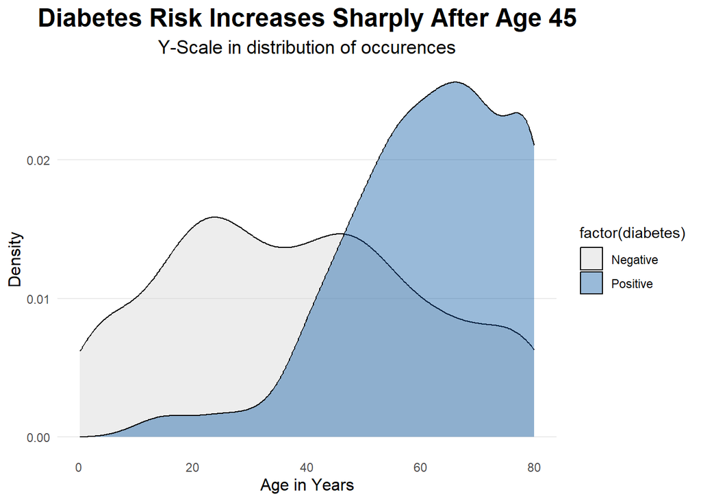

```r
AgeDensityPlot <- ggplot(diabetesdata, aes(x = age, fill = factor(diabetes))) +
  geom_density(alpha = 0.4) +
  scale_fill_manual(values = c("Negative" = "#d3d3d3", "Positive" = "#00539F")) +
  labs(title = "Diabetes Risk Increases Sharply After Age 45",
       subtitle = "Y-Scale in distribution of occurences",
       y = "Density",
       x = "Age in Years") +
  theme_minimal() +
  theme(plot.title = element_text(hjust = 0.5, size = 18, face = "bold"),
        plot.subtitle = element_text(hjust = 0.5, size = 13.5),
        axis.title = element_text(size = 12),
        panel.grid.major.x = element_blank(),   #Get rid of horizontal lines
        panel.grid.minor = element_blank())
AgeDensityPlot
```

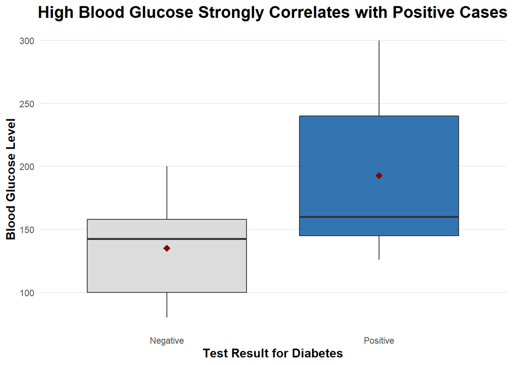

```r
BGLboxplot <- ggplot(diabetesdata) +
  geom_boxplot(aes(x = diabetes, y = blood_glucose_level, fill = diabetes),
               alpha = 0.8, show.legend = FALSE) +
  stat_summary(aes(x = diabetes, y = blood_glucose_level),
               fun = mean, geom = "point", shape = 18, size = 3, color = "darkred") +
  scale_fill_manual(values = c("Negative" = "#d3d3d3", "Positive" = "#00539F")) +

  labs(title = "High Blood Glucose Strongly Correlates with Positive Cases",
       y = "Blood Glucose Level",
       x = "Test Result for Diabetes") +
  theme_minimal() +
  theme(plot.title = element_text(hjust = 0.5, size = 16, face = "bold"),
        axis.title = element_text(size = 12, face = "bold"),
        panel.grid.major.x = element_blank(),
        panel.grid.minor = element_blank())
BGLboxplot
```

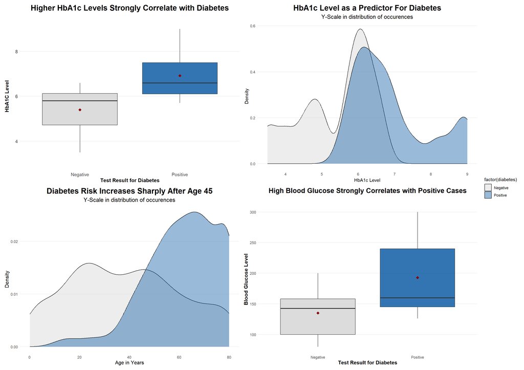

```r
library(patchwork)
Dashboard <- (HBA1cBoxPlot | HBA1cDensityPlot) / (AgeDensityPlot | BGLboxplot)
Dashboard <- Dashboard + plot_layout(guides = "collect")
Dashboard
```

```r
ggsave("FinalExam-Dashboard.png", Dashboard, width = 17, height = 12, dpi = 300)
png("BoxWhiskerPlot.png", width = 800, height = 600)
print(BoxWhiskerPlot)
```